# 第6讲笔记

定量数据分析

# 改变世界的方程

$$P(x) = \frac{1}{\sigma \sqrt{2 \pi}}e^{-(x-\mu)^2 / 2 \sigma^2}$$

# 正态分布／高斯分布

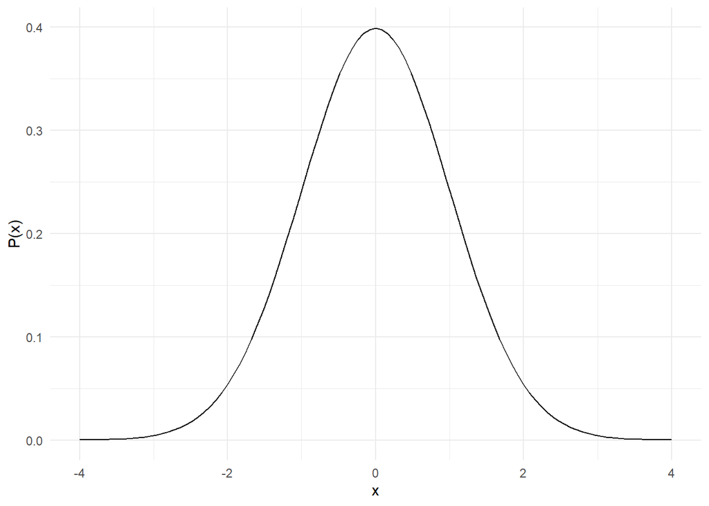

# 引言

- 我们一直在探讨工资以及工资差距。
- 我们观察到存在差距。
- 我们的数据只覆盖总体中的一个样本。
- 如果我们抽取的是另一个样本，会怎样？
- 新样本想必不会与原样本完全相同，对吗？
- 如果换一个样本，工资差距会不会消失？

# 抽样误差

- 这是统计学中的一个根本性问题。
- 我们可能在样本中发现了某种现象。
- 然而，如果抽取的样本不能代表总体，我们就可能得出错误结论。
- 我们将这种情况称为抽样误差。
- 来看一看我们的数据。

# 男性与女性的平均工资

```r
lfs %>% group_by(SEX) %>%
  summarise(mean_wage = mean(HOURPAY) %>% round(2)) %>%
  knitr::kable()
```

| 性别 | 平均工资 |
| --- | --- |
| 男性 | 22.48 |
| 女性 | 19.42 |

# 另一个样本

- 换一个样本，我们对平均值的估计可能不同。
- 我们只有一个样本（虽然也可以通过其他数据来源交叉验证）。
- 作为思想实验，假设这份数据就是总体。
- 从中随机抽样，看看会得到什么结果。
- R 可以帮我们完成这个过程。不必担心代码，只需要关注结果。
- 我们将抽取5个样本，每个样本包含200人。

# 平行宇宙

| 样本 | 男性 | 女性 | 差值 |
| --- | --- | --- | --- |
| 1 | 22.79 | 19.69 | -3.10 |
| 2 | 22.96 | 19.33 | -3.63 |
| 3 | 24.89 | 19.17 | -5.72 |
| 4 | 23.34 | 18.55 | -4.79 |
| 5 | 23.51 | 18.09 | -5.42 |

# 问题所在

- 在每一个平行宇宙中，我们都会抽取不同的样本。
- 我们身处其中某一个平行宇宙，只观察到了一个样本。
- 我们如何知道自己处于哪一个？
- 我们的样本具有代表性吗？
- 还是说，我们的样本严重缺乏代表性？

# 绘制平行宇宙的结果

- 首先画出不同样本中观察到的差异。
- 先绘制5个样本的结果。
- 之后逐步增加样本数量。

# 5个样本的结果

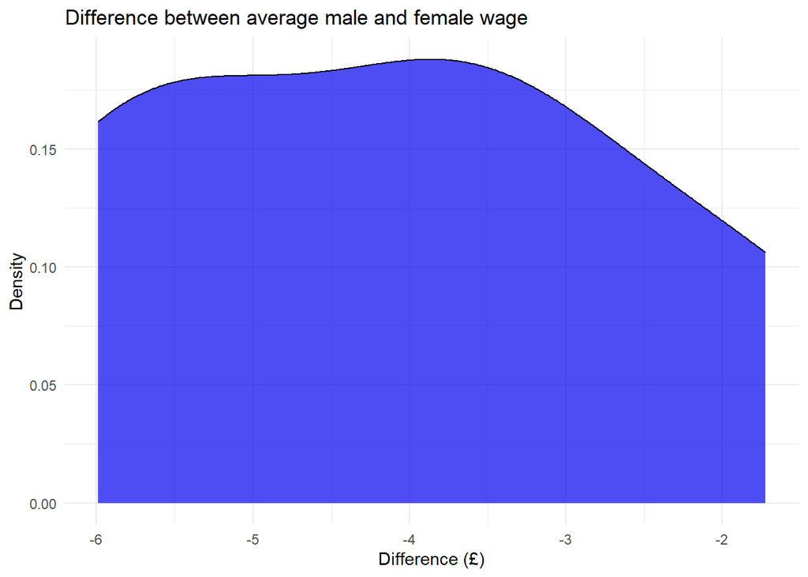

# 50个样本的结果

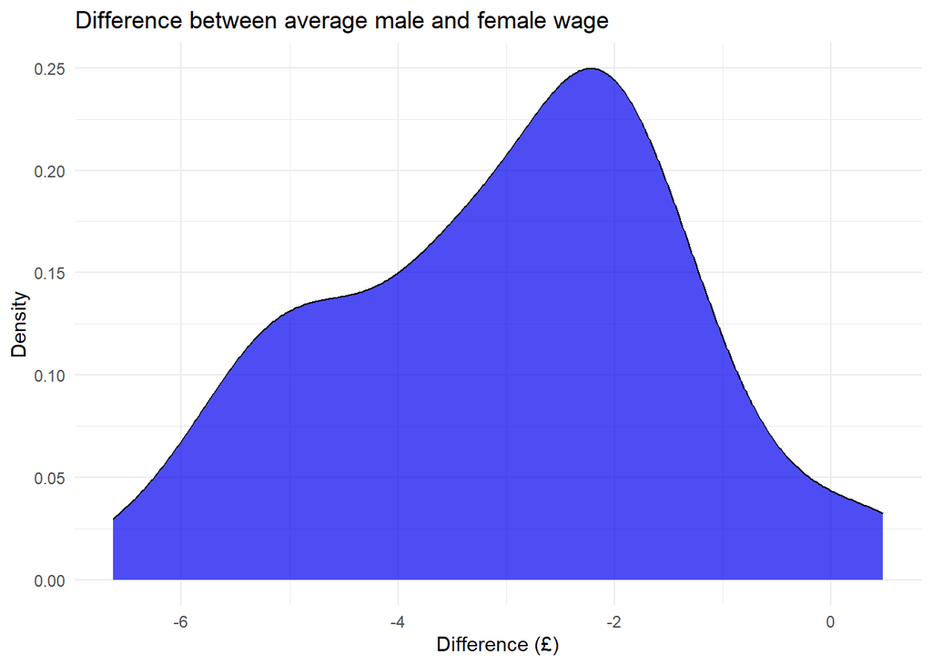

# 100个样本的结果

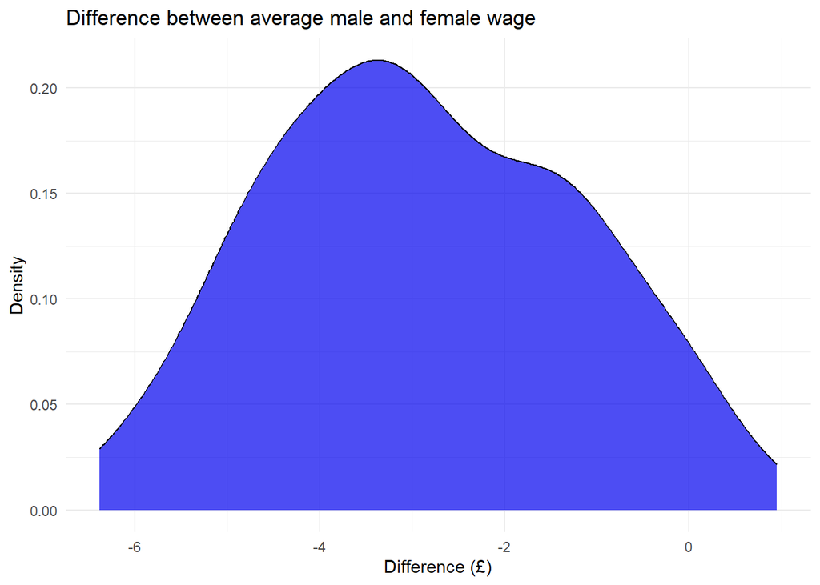

# 1,000个样本的结果

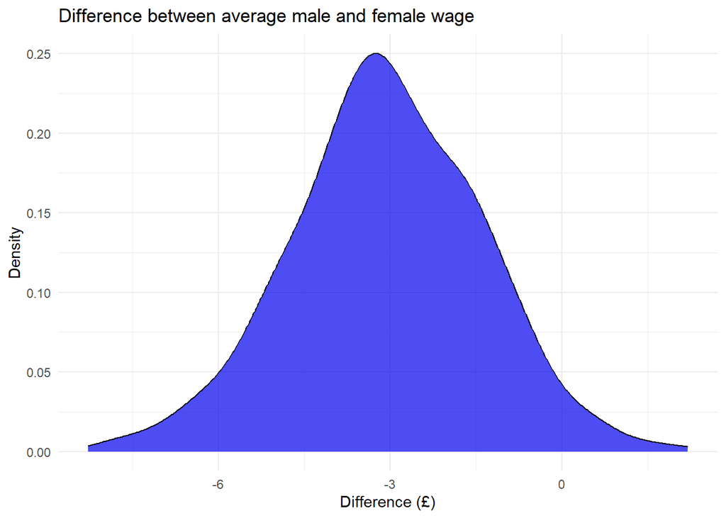

# 1,000个样本的结果

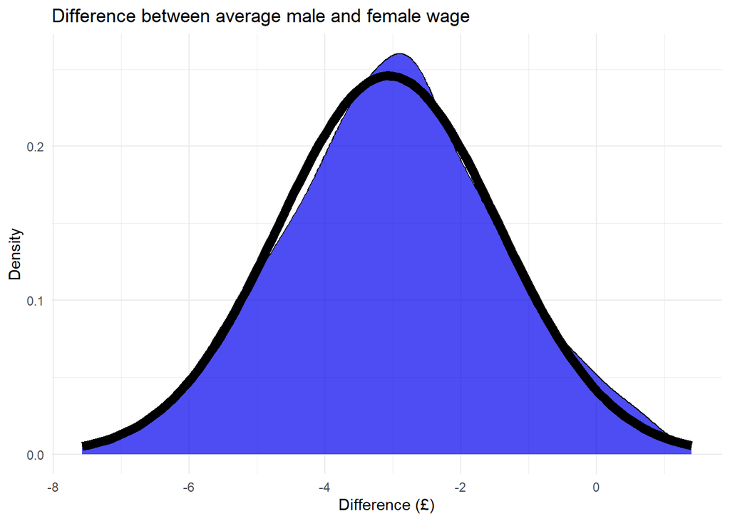

# 神奇的发现

- 希望你还记得本讲一开始看到的图形。
- 事实证明，对重复抽样计算得到的差异估计值，呈现出正态分布。
- 此外，如果基于一个样本计算某变量的均值，再反复重新抽样，所得到的均值估计也会呈正态分布（在适当条件下近似成立）。
- 这种现象被称为中心极限定理，是统计推断的基础。

# 我们能用它做什么？

- 中心极限定理的妙处在于，它让我们能够表达估计的不确定性。
- 在这里，我们想知道观察到的男女工资差距是否由抽样误差造成。
- 换句话说，我们想知道总体中的真实工资差距是否可能为零。
- 如果没有观察整个总体，我们就无法完全确定。
- 但我们可以对相关概率作出判断。
- 在此之前，先谈谈概率是什么。

# 贝叶斯概率与频率学派概率

- 本课程（与多数同类课程一样）将主要从经典概率／频率学派的角度讨论概率。
- 我们也可以采用贝叶斯方法理解概率。
- 频率学派将概率理解为事件发生的频率。
- 举个例子，来看性别变量的频数表。

| 性别 | 人数 | 比例 |
| --- | --- | --- |
| 男性 | 3410 | 0.46 |
| 女性 | 3937 | 0.54 |

# 将概率理解为频率

- 我将从我们感兴趣的总体中随机选出一个人。
- 这个人是男性的概率是多少？
- 查看频数表中男性所占的比例，就能得到答案。
- 这就是我们对从总体随机抽到男性这一概率的最佳估计。
- 这是概率的一个关键思想。
- 概率的计算与使用要遵循一系列规则。
- 由于本课程侧重应用，我们不必过分纠结这些规则的细节。

# 概率的公理与推论

- $0 \leq P(A) \leq 1$
- $P(\Omega) = 1$
- $P(\emptyset) = 0$
- $P(\bar{A}) = 1 - P(A)$
- $P(A_1 \cup A_2) = P(A_1) + P(A_1)$, if $A_1$ and $A_2$ are disjoint
- $P(A_1 \cup A_2) = P(A_1) + P(A_2) - P(A_1 \cap A_2)$
- $P(A) \leq P(B)$, if $A \subseteq B$

# 规则1

- $0 \leq P(A) \leq 1$
- A 是一个可能发生的事件。
- A 发生的概率 P(A) 必须介于0和1之间。
- 根据定义，所有概率都必须处于0到1之间。
- 如果算出的概率小于0或大于1，那么计算一定出了问题。

# 规则2

- $P(\Omega) = 1$
- $\Omega$ is known as the sample space
- Ω 表示所有可能结果构成的集合，即样本空间。
- 样本空间的子集称为事件。
- 因此可以说：$P(\Omega) = 1$。
- 样本空间中至少会发生某个事件。
- 必然事件的概率为1。

# 规则3

- $P(\emptyset) = 0$
- $\Omega$ is the set of all events
- $\emptyset$ is the empty or null set
- 空集中没有任何事件，因此其概率为零。
- 不可能事件的概率为0，也就是说它不会发生。

# 规则4

- $P(\bar{A}) = 1 - P(A)$
- 如果事件 A 发生的概率是 $P(A)$，
- 那么 A 不发生的概率就是 $1-P(A)$。
- 换言之，非 A 的概率为 $P(\bar{A}) = 1 - P(A)$。
- $\bar{A}$ is known as a complementary event

# 规则5

- $P(A) \leq P(B)$, if $A \subseteq B$
- $\subseteq$ is the notation for subset
- 如果 A 是 B 的子集，那么 A 发生的可能性不可能高于 B。
- 假设明天下雨的概率是0.6。
- 那么明天同时下雨且刮风的概率不可能高于0.6。

# 规则6

- $P(A_1 \cup A_2) = P(A_1) + P(A_2)$, $A_1 \cap A_2 = \emptyset$
- 这是规定如何组合概率的规则之一。
- 在集合论中，$\cup$ 表示并集，$\cap$ 表示交集。
- $A_1 \cup A_2$ are the objects belonging to set $A_1$ or $A_2$
- 如果两个事件无法同时发生（即互斥），则有：$P(A_1 \cup A_2) = P(A_1) + P(A_2)$。

# 规则7

- $P(A_1 \cup A_2) = P(A_1) + P(A_2) - P(A_1 \cap A_2)$
- $A_1 \cap A_2$ is the probability that $A_1$ and $A_2$ happen at the same time
- 如果 $A_1 \cap A_2 \neq \emptyset$，那么计算 $P(A_1 \cup A_2)$ 时应遵循：$P(A_1 \cup A_2) = P(A_1) + P(A_2) - P(A_1 \cap A_2)$。
- 如果不减去 $P(A_1 \cap A_2)$，就会发生重复计数。

# 条件概率

$$P(A|B) = \frac{P(A \cap
B)}{P(B)}$$

# 贝叶斯定理

$$P(A|B) = \frac{P(A \cap B)}{ P(B)} =
\frac{P(B|A)P(A)}{P(B)}$$

# 我们已经知道什么？

- 我们知道，反复抽样得到的工资差距估计将呈正态分布。
- 密度曲线下方的面积可以解释为概率。
- 为了方便计算，可以将工资差距估计值标准化。
- 这样就可以使用标准正态分布。
- 标准正态分布的均值为0，标准差为1。
- 如果观察到的工资差距完全由抽样误差造成，那么均值应当为零。
- 因此，我们从估计值中减去0，再除以该差值的标准差。

# 差值的标准差

- 如果已知研究群体在总体中的标准差，就可以用下式计算差值的标准误（SE）：

$$se_{\bar{X}_M - \bar{X}_F} =
\sqrt{\frac{\sigma_M^2}{N_M} + \frac{\sigma_F^2}{N_F}}$$
- $\sigma_i^2$ - Population variance of group $i$

- $N_j$ - Sample size of group $j$

# 汇总起来

- 我们将按以下步骤计算所谓的Z分数：
  - 减去期望均值（假设为0）
  - 除以标准误
  - 所得结果将服从标准正态分布。

$$Z = \frac{\bar{X}_M - \bar{X}_F}{
se_{\bar{X}_M - \bar{X}_F}}$$

# 问题

- 我们不知道总体的标准差。
- 暂且略过这一点，使用样本标准差。
- 稍后再回来讨论这一问题。

| 性别 | 人数 | 平均工资 | 工资方差 |
| --- | --- | --- | --- |
| 男性 | 3410 | 22.48 | 161.21 |
| 女性 | 3937 | 19.42 | 104.63 |

# 计算Z值

$$Z = \frac{(22.48 -
19.42)-0}{\sqrt{\frac{161.21}{3410} + \frac{104.63}{3937}}} =
11.26$$

# 结果解释

- 如果总体中的真实工资差距为零：
  - 那么Z值应接近零。
  - 我们不太可能观察到远离零的Z值。
- 如果观察到较大的差异，那么我们可能处于以下两种情况之一：
  1. 总体中的工资没有差别，但我们抽到了一个非常反常的样本。
  2. 两组总体均值确实存在差别，此时观察到的Z值并不罕见。

# 标准正态分布

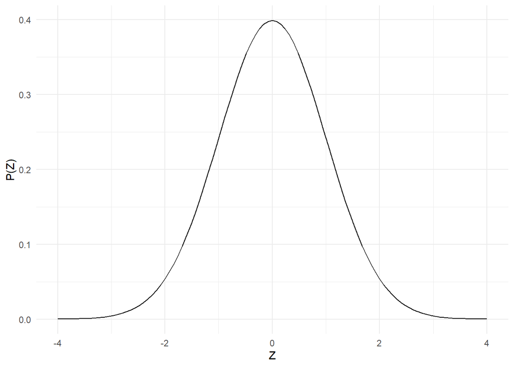

# 我们能看出什么？

- 分布中的大部分数据集中在零附近。
- 观察到小于−2或大于2的值，概率看起来相当低。
- 事实上，如果总体工资差距为零，那么Z值有95%的概率落在−1.96至1.96之间。
- 在本例中，Z值为11.26。

# 标准正态分布

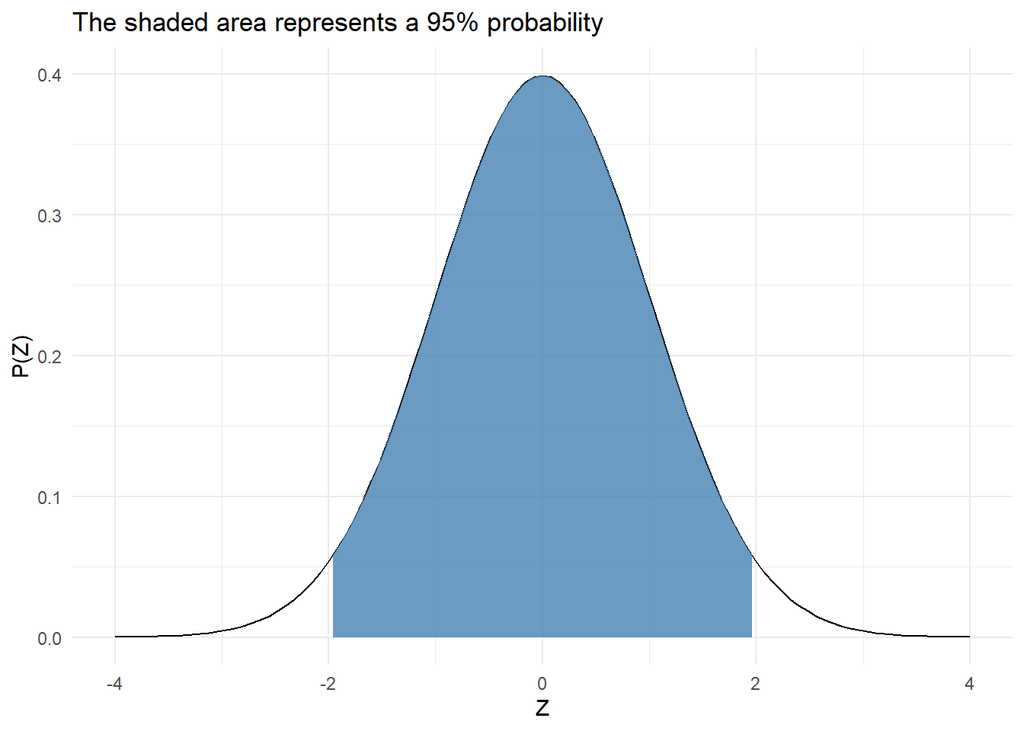

# 计算概率

- 我们想知道所观察到的工资差距是否来自抽样误差。
- 如果总体中的工资差距为零，那么刚才的曲线可以告诉我们不同Z值出现的概率。
- 我们想知道出现与观察值一样极端或更极端的Z值的概率。
- 可以使用微积分求解，也可以直接请R计算。
- 过去，人们需要在统计表书籍中查找这些概率。

# 使用R获取概率

```r
1-pnorm(11.26)
```

```
## [1] 0
```

- 本例的概率非常低，以至于R将它四舍五入显示为0。
- 概率并不真的等于0（我们仍可能判断错误），但它非常小。

# 作出判断

- 如果总体不存在工资差距，那么观察到Z值11.26的概率几乎为零。
- 因此，更合理的解释是总体中的工资确实存在差异。
- 当然，我们也会遇到概率没有这么低的情况。
- 惯例上，当概率小于或等于0.05时，我们拒绝“观察到的差异只是由抽样误差导致”这一假设。
- 我们把0.05称为显著性水平，有时用希腊字母 $\alpha$ 表示。

# 总体标准差

- 前面提到，这个Z检验假设我们知道总体标准差。
- 但我们并不知道，因此使用了样本标准差。
- 这引入了额外的不确定性，会影响概率计算。
- 都柏林健力士啤酒厂的一位聪明研究者找到了解决办法。
- 我们不再使用标准正态分布，而是使用t分布。
- t分布的形状随样本量变化（更准确地说，随自由度变化）。
- 当观测数量足够大时，t分布会趋近于标准正态分布。

# t分布

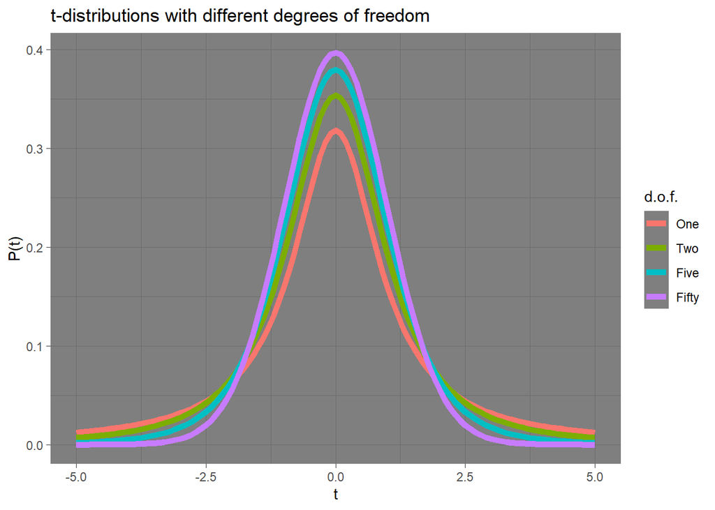

# t检验

- 可以让R计算t值及其对应概率。
- 这就是所谓的t检验。
- 开展检验前，必须明确我们要检验什么。
  1. 我们的原假设是什么？
  2. 我们的备择假设是什么？
  3. 我们的显著性水平是多少？

# 原假设

- 我们的研究假设是总体中的男女平均工资存在差异。
- 我们通过定义“二者相等”的原假设来开展检验。
- 然后尝试证明这样的假设与收集到的数据不一致，以便将其拒绝。
- 原假设可以写成：

$$H_0: \mu_{Male} =
\mu_{Female}$$

# 备择假设

- 当我们拒绝原假设时，备择假设就是我们认为成立的主张。
- 我们可以考虑以下三种备择假设：
  1. $H_A: \mu_{Male} \neq \mu_{Female}$
  2. $H_A: \mu_{Male} < \mu_{Female}$
  3. $H_A: \mu_{Male} > \mu_{Female}$
- 通常我们使用第一种，即所谓双侧检验或双尾检验。
- 如果认为差异只可能朝某个方向出现，则可以采用第二种或第三种。

# 显著性水平

- 在这里其实没有太多需要选择的。
- 惯例上，我们使用0.05的显著性水平。
- 如果称为p值的概率小于或等于0.05，我们就拒绝原假设。
- 否则，我们不能拒绝原假设（但绝不能说“接受原假设”）。

# 在R中执行t检验

- R有一个专门执行t检验的函数，名字很直观：t.test()。
- 函数参数可以有多种指定方法。
- 我建议使用公式写法：HOURPAY ~ SEX。
- 它检验因变量HOURPAY的平均值如何随自变量SEX的组别而变化。
- 还必须提供data参数，让函数知道在哪里查找变量。

# 检验不同性别的工资差异

```r
t.test(HOURPAY ~ SEX, data=lfs)
```

```
##
##  Welch Two Sample t-test
##
## data:  HOURPAY by SEX
## t = 11.257, df = 6531.3, p-value < 2.2e-16
## alternative hypothesis: true difference in means between group Male and group Female is not equal to 0
## 95 percent confidence interval:
##  2.526349 3.591807
## sample estimates:
##   mean in group Male mean in group Female
##             22.48338             19.42430
```

# 科学计数法

- 科学计数法用于表示特别小或特别大的数字。
- 任何数字都可以写成科学计数法。
- 将一个数字乘以10的某次幂即可。
- 1,530,000可写为 $1.53 \times 10^6$。
- 0.000000023可写为 $2.3 \times 10^{-8}$。
- 指数告诉我们小数点应该移动多少位，以及向哪个方向移动。
- 在R中运行 options(scipen = 999) 可以尽量避免科学计数法显示。
- 运行 options(scipen = 0) 可以恢复默认设置。

# 结果解释

# 置信区间

- 请注意，输出中还报告了一个置信区间。
- 它为我们关心的参数（这里是工资差距）提供一个合理的数值范围。
- 按这种方法重复构建置信区间，100次中大约有95次会包含总体参数。
- 有人喜欢将其理解为“我们有95%的信心认为参数位于该区间内”。
- 严格来说，这样的概率解释并不正确；它更接近贝叶斯统计中的可信区间。

# 错误类型

- 拒绝原假设时，我们也可能判断错误。
- 若原假设实际上为真，却被我们拒绝，就犯了第一类错误（Type I error）。
- 若原假设实际上为假，却未被我们拒绝，就犯了第二类错误（Type II error）。
- 一般来说，第一类错误通常被视为更严重，因为拒绝原假设意味着我们作出了某项知识主张。
- 有些人喜欢用刑事司法来类比：
  - 第一类错误类似于将无辜者判为有罪。
  - 第二类错误类似于让有罪者获得释放。

# t检验是一个特殊情形

- t检验是线性模型的一个特殊情况。
- 在课程后半部分，我们将大量使用线性模型。
- 它使我们能够建立复杂、精细的模型。
- 使用线性模型进行类似t检验的分析也相当容易。
- 我们将使用lm()函数。
- 还需要把结果传给summary()函数。

# 为什么使用线性模型？

- 线性模型用直线方程表达变量间的关系。
- 你可能记得直线方程写作 $y_i = \alpha + \beta\cdot x_i$。
- $\alpha$ shows where the line *intercepts* the vertical axis
- $\beta$ shows the *slope* of the line
- 在本例中，$\alpha$ 代表性别参照组的工资。
- $x$ is a dummy variable, which we define as being equal to zero when the person is male, and 1 when they are female
- $\beta$ therefore represents the difference between Female and Male

# 线性模型中的t检验

```r
lm(HOURPAY ~ SEX, data=lfs) %>% summary()
```

```
##
## Call:
## lm(formula = HOURPAY ~ SEX, data = lfs)
##
## Residuals:
##     Min      1Q  Median      3Q     Max
## -16.033  -7.639  -3.384   4.256  79.396
##
## Coefficients:
##             Estimate Std. Error t value Pr(>|t|)
## (Intercept)  22.4834     0.1959  114.76   <2e-16 ***
## SEXFemale    -3.0591     0.2676  -11.43   <2e-16 ***
## ---
## Signif. codes:  0 '***' 0.001 '**' 0.01 '*' 0.05 '.' 0.1 ' ' 1
##
## Residual standard error: 11.44 on 7345 degrees of freedom
## Multiple R-squared:  0.01748,    Adjusted R-squared:  0.01734
## F-statistic: 130.6 on 1 and 7345 DF,  p-value: < 2.2e-16
```

# 结果解释

- 这里有很多数字。
- Estimate（估计值）列提供了我们关心的参数。
- 截距表示虚拟变量等于零时的平均值。
- 因此男性平均工资为22.48。
- 男女平均工资之差为−3.06。
- 女性平均工资等于截距加上女性对应的回归系数，即19.42。

# 结果解释

- Std. Error（标准误）表示估计值的精确程度。
- 和之前一样，用估计值除以标准误即可得到t值。
- Pr(>|t|)一列给出对应的p值。
- 每一行都在检验“该估计值在总体中的真实值等于零”这一原假设。
- 第一行检验男性平均工资是否为零。
- 这对我们的研究并不是一个特别有用的检验。

# 结果解释

- 下一行检验男女之间的差距是否为零。
- 和之前一样，我们拒绝原假设，认为存在差异。
- 请注意，这些结果与前面的并不完全相同（自由度不同）。
- 我们稍后会继续讨论。

# 总结

- 我们已经迈出了统计推断的第一步。
- 我们的核心问题是：在样本中观察到的差异，能否推广到总体？
- 概率规则和中心极限定理使我们能够估计：数据中观察到的现象仅由抽样误差造成的概率有多大。
- 课程余下内容将在这一基本思想上继续扩展。